# Bernoulli Numbers

### **NOTES ON STATISTICS, PROBABILITY and MATHEMATICS**

### Bernoulli Numbers:

Bernoulli numbers are important in many fields. They can be generated by inverting Pascal’s triangle - or the matrix form of Pascal’s triangle, excluding the $1$’s on the right of triangle (and performing an alternate minus sign pre-“conditioning”, as explained [here](https://youtu.be/fw1kRz83Fj0?t=1189)):

#### FINDING BERNOULLI NUMBERS IN THE INVERTED MATRIX OF PASCAL’S TRIANGLE:

The “second Pascal matrix” is the lower triangular form of the Pascal matrix without the diagonal of $1$’s:

```r
library(MASS)

n = 11
second.Pascal = matrix(0,n,n)
for(i in 1:n){
  for(k in 0:(i-1))
    second.Pascal[i,k+1] = choose(i,k)
}
(M = second.Pascal)
```

```
##       [,1] [,2] [,3] [,4] [,5] [,6] [,7] [,8] [,9] [,10] [,11]
##  [1,]    1    0    0    0    0    0    0    0    0     0     0
##  [2,]    1    2    0    0    0    0    0    0    0     0     0
##  [3,]    1    3    3    0    0    0    0    0    0     0     0
##  [4,]    1    4    6    4    0    0    0    0    0     0     0
##  [5,]    1    5   10   10    5    0    0    0    0     0     0
##  [6,]    1    6   15   20   15    6    0    0    0     0     0
##  [7,]    1    7   21   35   35   21    7    0    0     0     0
##  [8,]    1    8   28   56   70   56   28    8    0     0     0
##  [9,]    1    9   36   84  126  126   84   36    9     0     0
## [10,]    1   10   45  120  210  252  210  120   45    10     0
## [11,]    1   11   55  165  330  462  462  330  165    55    11
```

The equation for the sums of powers of natural numbers can extracted from this second Pascal matrix with some sign changes in alternating diagonals:

```r
m = M * (((row(M) - col(M))%%2==1) * -1) +
M * (((row(M) - col(M))%%2==0) * 1)
m
```

```
##       [,1] [,2] [,3] [,4] [,5] [,6] [,7] [,8] [,9] [,10] [,11]
##  [1,]    1    0    0    0    0    0    0    0    0     0     0
##  [2,]   -1    2    0    0    0    0    0    0    0     0     0
##  [3,]    1   -3    3    0    0    0    0    0    0     0     0
##  [4,]   -1    4   -6    4    0    0    0    0    0     0     0
##  [5,]    1   -5   10  -10    5    0    0    0    0     0     0
##  [6,]   -1    6  -15   20  -15    6    0    0    0     0     0
##  [7,]    1   -7   21  -35   35  -21    7    0    0     0     0
##  [8,]   -1    8  -28   56  -70   56  -28    8    0     0     0
##  [9,]    1   -9   36  -84  126 -126   84  -36    9     0     0
## [10,]   -1   10  -45  120 -210  252 -210  120  -45    10     0
## [11,]    1  -11   55 -165  330 -462  462 -330  165   -55    11
```

The Faulhaber matrix is the inverse:

```r
(Faulhaber = fractions(solve(m)))
```

```
##       [,1]  [,2]  [,3]  [,4]  [,5]  [,6]  [,7]  [,8]  [,9]  [,10] [,11]
##  [1,]     1     0     0     0     0     0     0     0     0     0     0
##  [2,]   1/2   1/2     0     0     0     0     0     0     0     0     0
##  [3,]   1/6   1/2   1/3     0     0     0     0     0     0     0     0
##  [4,]     0   1/4   1/2   1/4     0     0     0     0     0     0     0
##  [5,] -1/30     0   1/3   1/2   1/5     0     0     0     0     0     0
##  [6,]     0 -1/12     0  5/12   1/2   1/6     0     0     0     0     0
##  [7,]  1/42     0  -1/6     0   1/2   1/2   1/7     0     0     0     0
##  [8,]     0  1/12     0 -7/24     0  7/12   1/2   1/8     0     0     0
##  [9,] -1/30     0   2/9     0 -7/15     0   2/3   1/2   1/9     0     0
## [10,]     0 -3/20     0   1/2     0 -7/10     0   3/4   1/2  1/10     0
## [11,]  5/66     0  -1/2     0     1     0    -1     0   5/6   1/2  1/11
```

Compare to the slide on Mathologer:

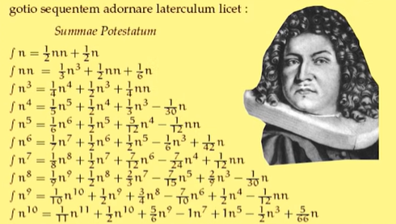

which is immediately apparent in the Faulhaber matrix, here with minimal rearrangements:

```
flipF = Faulhaber[, ncol(Faulhaber):1]

N = matrix(0,nrow(flipF),ncol(flipF))
for(j in 1:nrow(flipF)){
  for(i in 1:j)
    N[j,j -i+1] <- flipF[j, ncol(flipF) - i + 1]
}

rownames(N) <- c(paste('S',0:(nrow(N)-1)))
fractions(N)
```

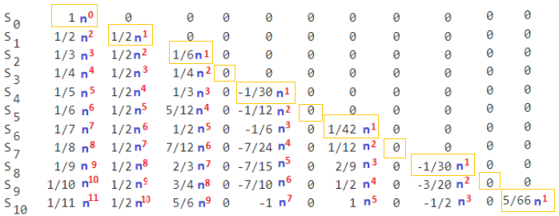

##### SUM OF POWERS

For instance, in the matrix above, named the Faulhaber matrix, the sum of the first $n$ natural numbers (to the power of $1$) would be given by:

$$S_1 = 1/2 \;n + 1/2 \; n^2=
\frac{n\;(n+1)}2$$

$$S_4= -1/30 \;n + 1/3 \; n^3 + 1/2 \; n^4
+ 1/5 \; n^5$$

The general closed form for the sum of powers is derived below (*).

The Bernoulli numbers are in the first column, and the rest of the numbers in each diagonal depends on that first value:

$$1/2 \quad 1/2 \quad 1/2 \quad 1/2 \quad
\dots$$
or

$$2/12 \quad 3/12 \quad 4/12 \quad 5/12
\quad 6/12 \quad 7/12 \quad \dots$$

Therefore the Bernoulli numbers can be extracted as:

```r
(Bernoulli = Faulhaber[,1])
```

```
##  [1]     1   1/2   1/6     0 -1/30     0  1/42     0 -1/30     0  5/66
```

The sum of each row in the Faulhaber matrix adds to $1$:

```r
rowSums(Faulhaber)
```

```
##  [1] 1 1 1 1 1 1 1 1 1 1 1
```

which is part of the method explained by John Conway in [here](https://youtu.be/Uy1B_eGXQ0g):

The difference between each natural number $x$ to the $s$ power, e.g. $x^s= 3^s$

in

$$1^s + 2^s + \color{red}{3}^s + 4^s+
\cdots + n^{s}$$

and the preceding sum to an immediately lower power:

$$1^{s-1} + 2^{s-1} + \color{red}{3}^{s-1}
+ 4^{s-1}+ \cdots + n^{s-1}$$

is

$$S_s(x)-S_{s-1}(s)=x^s$$

Differentiating,

$$S_s'(x)-S'_{s-1}(s)=s\;x^{s-1}$$

$$5\times\left(-1/30\; x + 1/3 \; x^3 +
1/2 \; x^4 + 1/5\; x^5\right)$$

and then integrating:

$$-1/12\; x^2 + 5/12 \; x^4 + 1/2 \; x^5 +
1/6\; x^6$$

Now for the punch-line all the factors have to add to $1$ because this equation must be valid for all sums up to a given natural number $n.$ Therefore if $n=1$ all the powers will be $1.$ Therefore, the missing number, i.e. the Bernoulli number is

$$B_5 = 1 + 1/12 - 5/12 - 1/2
-1/6=0$$

which is indeed the case.

#### CLOSED FORM AND GENERATING FUNCTION:

$$B_n=\sum_{k=0}^n\frac1{k+1}\sum_{j=0}^k(-1)^j\binom{k}{j}j^n,\quad
n\ge0$$

The exponential generating function is:

$$\frac{x}{e^x-1} = \sum_{k=0}^\infty B_k
\frac{x^k}{k!}$$
This is frightening, but using Wofram Alpha:

`series expansion of f(x) = x/(exp(x) -1)`

yieds the following monster:

$$1 - \frac 1 2 x + \frac 1{12} x^2 -
\frac 1{720}x^4 + \frac 1 {30240}x^6 - \frac 1{1209600} x^8+ \frac 1
{47900160}x^{10}-\frac {691}{1307674368000}x^{12}+\cdots$$

Not the Bernoulli numbers! So how to get them? Multiply each term $a_n$ by $n!$:

$$\begin{align}
1 \times 0! &= 1\\
-1/2 \times 1! &= -1/2 \\
1/12 \times 2! &= 1/6 \\
-1/720 \times 4! &= - 1/30 \\
1/30240 \times 6! & = 1/42 \\
-1/1209600 \times 8! &= -1/30 \\
1/47900160 \times 10! &= 5/66 \\
-691/1307674368000 \times 12! &= -691/2730
\end{align}$$

which are Bernoulli numbers:

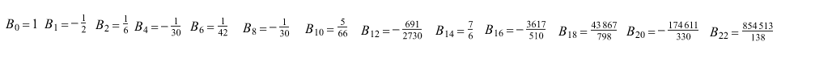

This can also be seen as follows:

1. Adding and subtracting in the numerator $t+\frac{t^2}{2!}+\frac{t^3}{3!}+\frac{t^4}{4!}+...$ the $t$ is eliminated:

$$\frac{t}{e^t-1}=\frac{t}{t+\frac{t^2}{2!}+\frac{t^3}{3!}+\frac{t^4}{4!}+...}=1+\frac{(1-1)t-\frac{t^2}{2!}-\frac{t^3}{3!}-\frac{t^4}{4!}-...}{t+\frac{t^2}{2!}+\frac{t^3}{3!}+\frac{t^4}{4!}+...}=1-\frac{+\frac{t^2}{2!}+\frac{t^3}{3!}+\frac{t^4}{4!}+...}{t+\frac{t^2}{2!}+\frac{t^3}{3!}+\frac{t^4}{4!}+...}$$
2. To now get the second Bernoulli coefficient, from the numerator we subtract from the numerator $\frac {t} {2} \small \left(t+\frac{t^2}{2!}+\frac{t^3}{3!}+\frac{t^4}{4!}+... \right)$:

$$\frac{t}{e^t-1}=1-\frac{t}{2}+\frac{+(\frac{1}{2}-\frac{1}{2!})t^2+(\frac{1}{2.2!}-\frac{1}{3!})t^3+(\frac{1}{2.3!}-\frac{1}{4!})t^4+...}{t+\frac{t^2}{2!}+\frac{t^3}{3!}+\frac{t^4}{4!}+...}=1-\frac{t}{2}+\frac{(\frac{1}{2.2!}-\frac{1}{3!})t^3+(\frac{1}{2.3!}-\frac{t^4}{4!})t^4+...}{t+\frac{t^2}{2!}+\frac{t^3}{3!}+\frac{t^4}{4!}+...}$$
3. And so forth

$$\frac{t}{e^t-1}=1-\frac{1}{2}t+\frac{\frac{1}{12}t^3+\frac{1}{24}t^4+...}{t+\frac{t^2}{2!}+\frac{t^3}{3!}+\frac{t^4}{4!}+...}=1-\frac{1}{2}t+\frac{1}{12}t^2+\frac{(\frac{1}{24}-\frac{1}{2.12})t^4+...}{t+\frac{t^2}{2!}+\frac{t^3}{3!}+\frac{t^4}{4!}+...}$$

##### (*) Closed form derivation:

The first series are (see [here](https://en.wikipedia.org/wiki/Faulhaber%27s_formula)):

$$\begin{align}
S_0(n) &= n\\
S_1(n) &= 1/2 \, n^2 + 1/2 \, n\\
S_2(n) &= 1/3 \, n^3 + 1/2 \,n^2 + 1/6 \,n\\
S_3(n) &= 1/4 \, n^4 + 1/2 \,n^3 + 1/4 \, n^2\\
S_4(n) &= 1/5 \, n^5 + 1/2 \,n^4 + 1/3 \, n^3 - 1/30 \, n\\
S_5(n) &= 1/6 \, n^6 + 1/2 \,n^5 + 5/12\, n^4 - 1/12 \, n^2\\
S_6(n) &= 1/7 \, n^7 + 1/2 \,n^6 + 1/2 \, n^5 - 1/6 \, n^3 + 1/42
\,n)
\end{align}$$

A common factor corresponding to the power can be extracted in front for each sum $S_p(n) \mapsto 1/(p+1)$:

$$\begin{align}
S_0(n) &= 1\,n\\
S_1(n) &= 1/2 \; (n^2 + n)\\
S_2(n) &= 1/3 \; (n^3 + 3/2 \,n^2 + 1/2 \,n)\\
S_3(n) &= 1/4 \; (n^4 + 2 \,n^3 + n^2)\\
S_4(n) &= 1/5 \; (n^5 + 5/2 \,n^4 + 5/3 \,n^3 - 1/6 \, n)\\
S_5(n) &= 1/6 \; (n^6 + 3 \,n^55 + 5/2\, n^4 - 1/2 \,^2)\\
S_6(n) &= 1/7 \; (n^7 + 7/2 \,n^6 + 7/2 \, n^5 - 7/6 \, n^3 + 1/6
\,n)
\end{align}$$

Extracting common multiples by column:

$$\begin{align}
S_0(n) &= 1\,n\\
S_1(n) &= 1/2 \; (n^2 +2 (1/2) \,n)\\
S_2(n) &= 1/3 \; (n^3 +3 (1/2) \,n^2 + 3 \,(1/6) \,n)\\
S_3(n) &= 1/4 \; (n^4 +4 (1/2) \,n^3 + 6 \,(1/6) \,n^2)\\
S_4(n) &= 1/5 \; (n^5 +5 (1/2) \,n^4 + 10 (1/6) \,n^3 - 5 (1/30)
n)\\
S_5(n) &= 1/6 \; (n^6 +6 (1/2) \,n^5 + 15 (1/6) \,n^4 - 15 (1/30)
n^2)\\
S_6(n) &= 1/7 \; (n^7 +7 (1/2) \,n^6 + 21 (1/6) \,n^5 - 35 (1/30)
n^3 + 7(1/42)n)
\end{align}$$

Now the integers are all binomial coefficients corresponding to the row:

$$\small\begin{align}
S_0(n) &= 1\; \; \left(\binom 1 0 \color{red} 1\,n\right)\\
S_1(n) &= \frac 1 2 \; \left(\binom 2 0 n^2 +\binom 2 1
\left(\color{red}{\frac 1 2} \right) \,n \right)\\
S_2(n) &=\frac 1 3 \; \left(\binom 3 0 n^3 +\binom 3 1 \left(\frac 1
2 \right) \,n^2 + \binom 3 2 \,\left(\color{red}{\frac 1 6} \right) \,n
\right)\\
S_3(n) &= \frac 1 4 \; \left(\binom 4 0 n^4 + \binom 4 1 \left(\frac
1 2 \right) \,n^3 + \binom 4 2 \,\left(\frac 1 6 \right) \,n^2 + \binom
4 3 \,\color{red} 0 \,n \right)\\
S_4(n) &= \frac 1 5 \; \left(\binom 5 0 n^5 + \binom 5 1 \left(\frac
1 2 \right) \,n^4 + \binom 5 2 \left(\frac 1 6\right) \,n^3 - \binom 5 3
0 \,n^2+ \binom 5 4 \left(\color{red}{\frac 1 {30}} \right) n\right)\\
S_5(n) &= \frac 1 6 \; \left(\binom 6 0 n^6 +\binom 6 1 \left(\frac
1 2 \right) \,n^5 + \binom 6 2 \left(\frac 1 6 \right) \,n^4 + \binom 6
3 0\,n^3 - \binom 6 4 \left(\frac 1{30} \right) n^2 + \binom 6 5
\color{red} 0\, n\right)\\
S_6(n) &= \frac 1 7 \; \left(\binom 7 0 n^7 + \binom 7 1 \left(\frac
1 2 \right) \,n^6 + \binom 7 2 \left(\frac 1 6 \right) \,n^5 + \binom 7
3 0\,n^4- \binom 7 4 \left(\frac 1 {30} \right) n^3 + \binom 7 5 0\,n^2
+ \binom 7 6 \left(\color{red}{\frac 1{42}} \right)n\right)
\end{align}$$

leading to the final formula:

$$S_p(n) = \frac 1{p+1} \left(
\sum_{k=1}^{p+1}\;\left(-1\right)^{\delta^k_p}\;\binom{p+1}k
B^-_{p+1-k}\;n^k
\right)$$

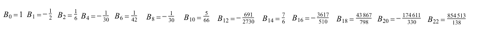

The actual proof is in this [Michael Penn presentation](https://youtu.be/pACLBI6ZQgw).

### Connections and Appearances of the Bernoulli Numbers:

#### Calculation of the zeta function for even multiples (Euler):

The Euler formula for even multiples of the the zeta function is:

$$\zeta(2 k)=\frac{(-1)^{k-1}(2 \pi)^{2 k}
B_{2 k}}{2(2 k) !}$$

#### Riemann zeta functional equation with Bernoulli numbers:

Riemann formulated the following equation linking the zeta function and Bernoulli numbers:

$$\zeta(1-k)=-\frac{B_{k}}{k}$$

#### Generalized Bernoulli numbers:

For a Dirichlet character $\chi,$ the functional Riemann equation right above can be extended to L-functions as:

$$L(1-k, \chi)=:-\frac{B_{k,
\chi}}{k}$$

#### Dirichlet L-functions:

L-functions are infinite sums of the form of a [Dirichlet series](https://en.wikipedia.org/wiki/Dirichlet_character#Applications):

$$L(s,
\chi)=\sum_{n=1}^\infty\frac{\chi_n}{n^s}$$
whereas Bernoulli numbers appear in the sums of $n$ powers, for $k$ a positive whole number:

$$1^k + 2^k + 3^k + \cdots +
n^k$$

Thinking of $k$ above as a negative number, there has to be a connection to the Dirichlet series or the Dirichlet characters $\chi_n,$ even though the L-functions sum to infinity, and the Bernoulli numbers appear in finite sums.

There is a relationship as in

$$\sum_{n \geq 0} B_{n, \chi}
\frac{T^{n}}{n !}=\sum_{a=1}^{f} \frac{\chi(a) T e^{a T}}{e^{f
T}-1}$$

in which $f$ is the *conductor* of the Dirichlet character $\chi,$ defined as:

*The conductor of a Dirichlet character $\chi$ modulo $q$ is the least positive integer $q_1$ dividing $q$ for which $\chi(n+kq_1)=\chi(n)$ for all $n$ and $n+kq_1$ coprime to $q$.* (From [here](https://www.lmfdb.org/knowledge/show/character.dirichlet.conductor)).

[Home Page](http://rinterested.github.io/statistics/index.html)

**NOTE: These are tentative notes on different topics for personal use - expect mistakes and misunderstandings.**